# EDA of REd Wine Quality by KHRYSTYNE TAYLOR

Other variable pairs that have a noteable relationship: -Fixed acidity: Density = 0.66 -Fixed acidity: Citric acid = 0.69 -Citric acid : Density = 0.36 -pH : Fixed acidity = -0.70 -Volatile acidity: Citric acid = -0.57 -pH: Citric acid = -0.517 -Alcohol: Density = -0.516

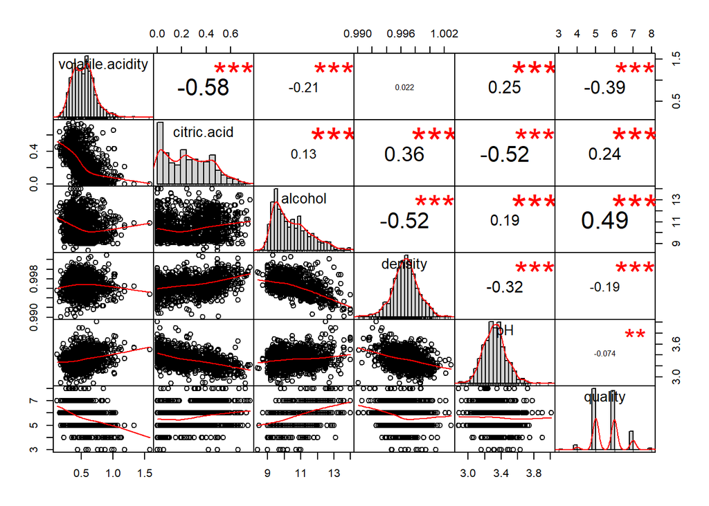

This function will allow us to plot and view the average, 1st, 2nd, and 3rd quantile, as well as, the correlation using stat_smooth of every graph plotted.

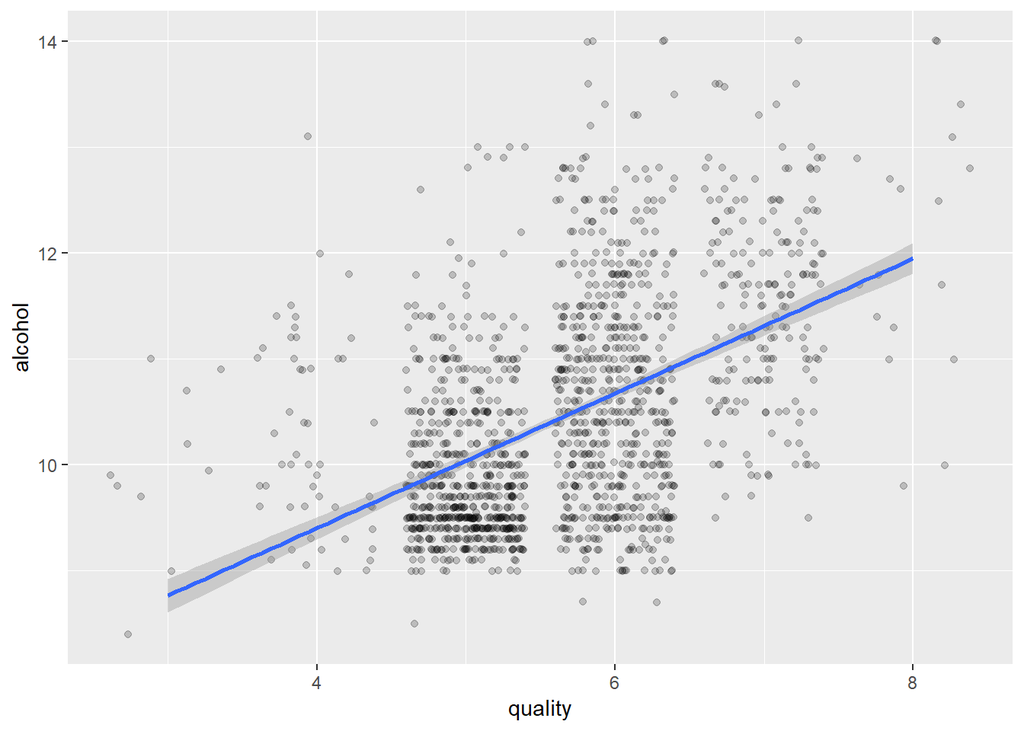

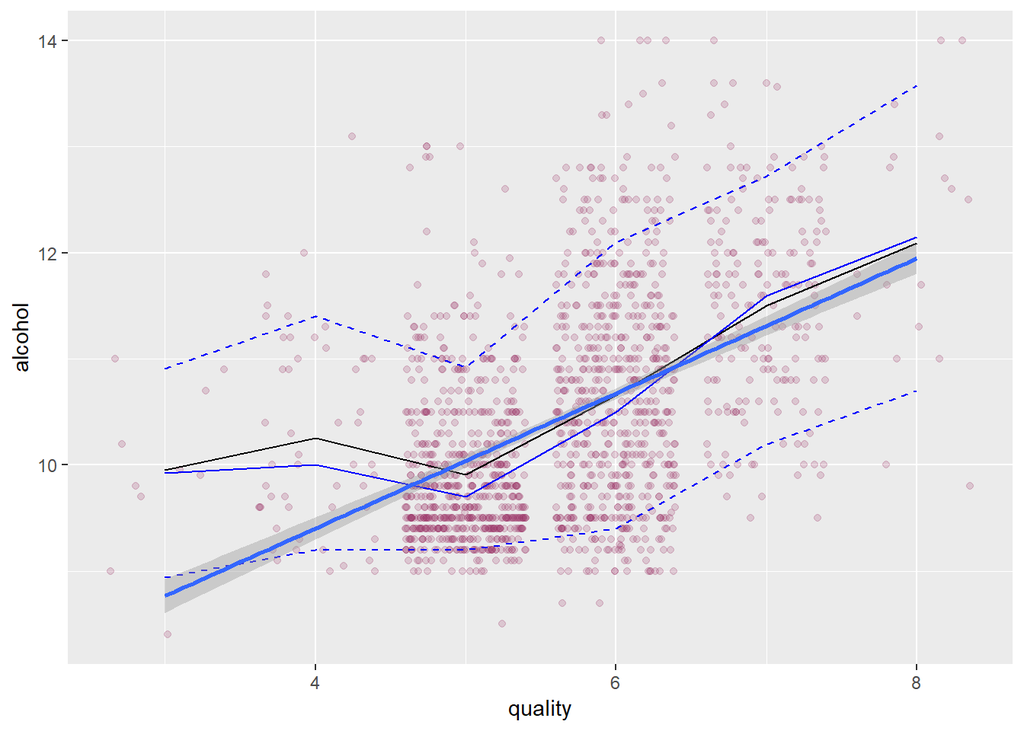

```
##
##   3   4   5   6   7   8
##  10  51 629 604 189  18
```

Quality and alcohol has a correlation of 0.49, which is a moderate positive relationship. From the results of the scatter plot it is safe to assume that as alcohol content increases so does the quality level of the wine. Most good quality wine (quality rating of 5.5 and higher) has an alcohol content between 9.5 - 13%.

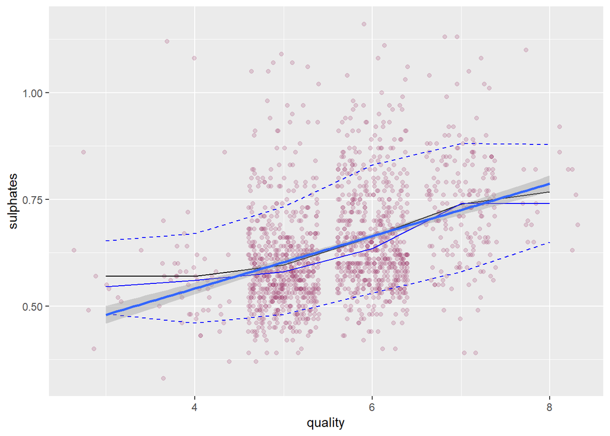

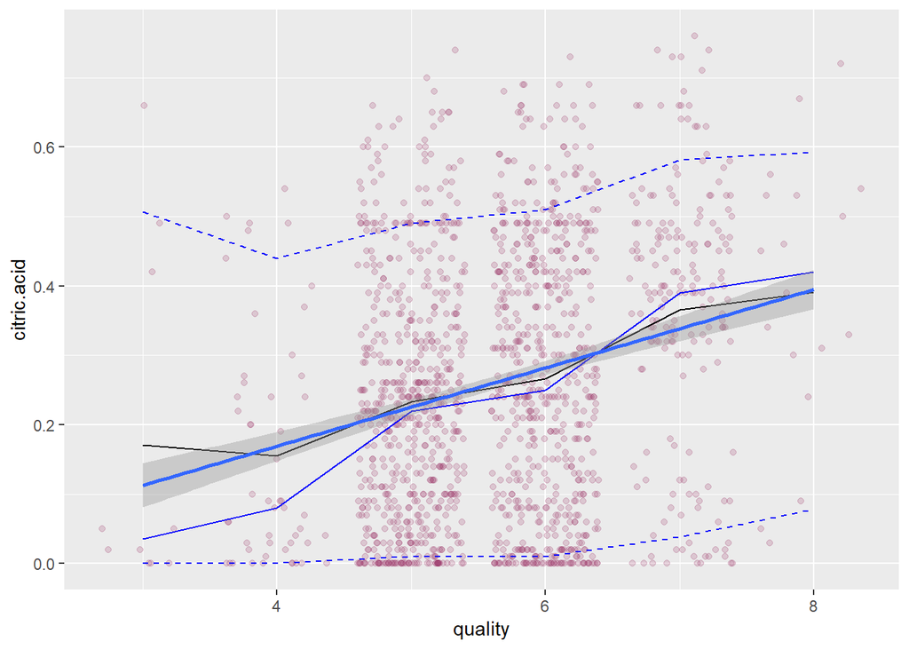

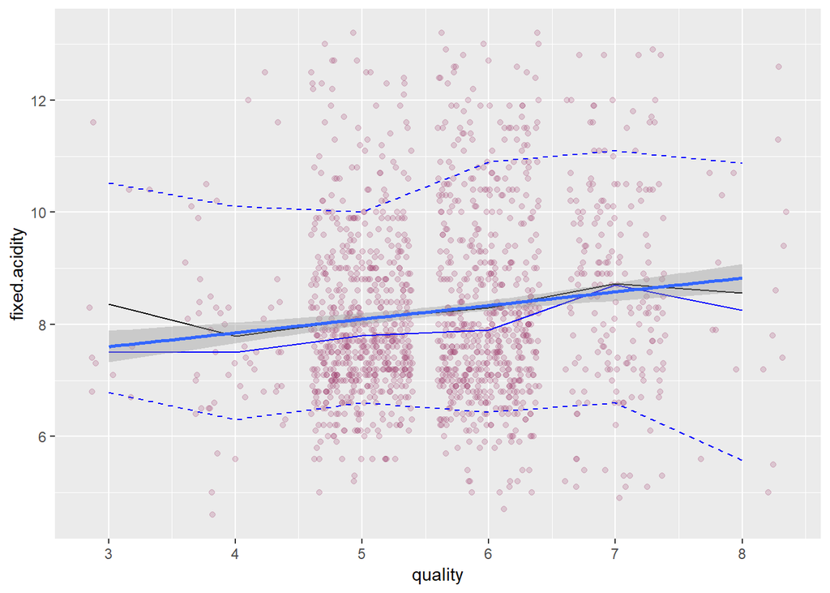

As with the relationship between quality and alcohol, sulphates, citric acid and fixed acidity (Although a weak uphill relationship) have a positive linear relationship with quality. As these factors increase so with the quality rating of the wine.

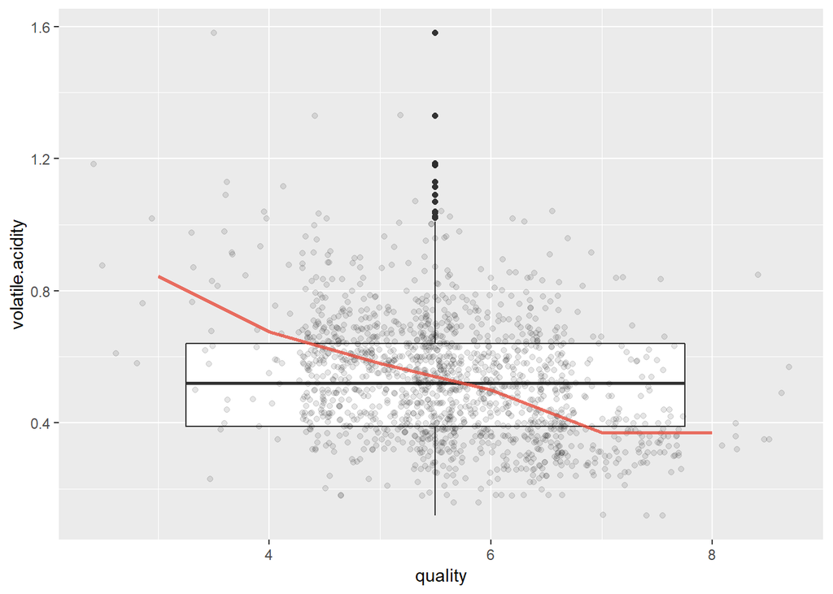

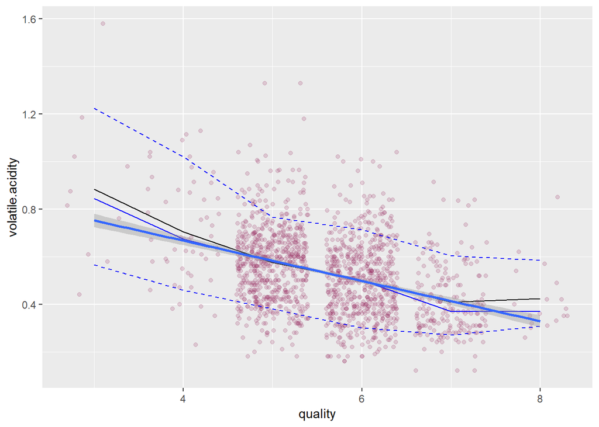

We can see that there is a negative correlation between quality and volatile acidity, with the correlation coefficient at -0.39. This indicates a weak downhill linear relationship. Therefore, as volotile acidity decreases, the quality score of wine increases, which makes perfect sense as too high levels of volatile acidity can lead to an unpleasant, vinegar taste.

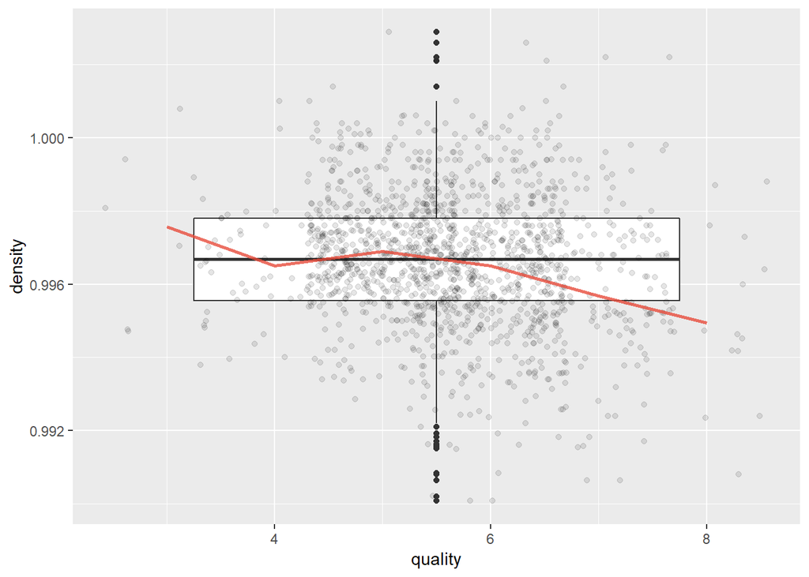

Our results seems to show that people prefer wine that is less dense, this is supported by r = -0.18. However, we should note that this is a very weak linear relationship as it is close to zero.

I will not be plotting graphs for the relationships between quality and total sulfur dioxide and quality and chlorides, because these, too, have a very weak negative linear relationship at -0.19 and 0.11, respectively.

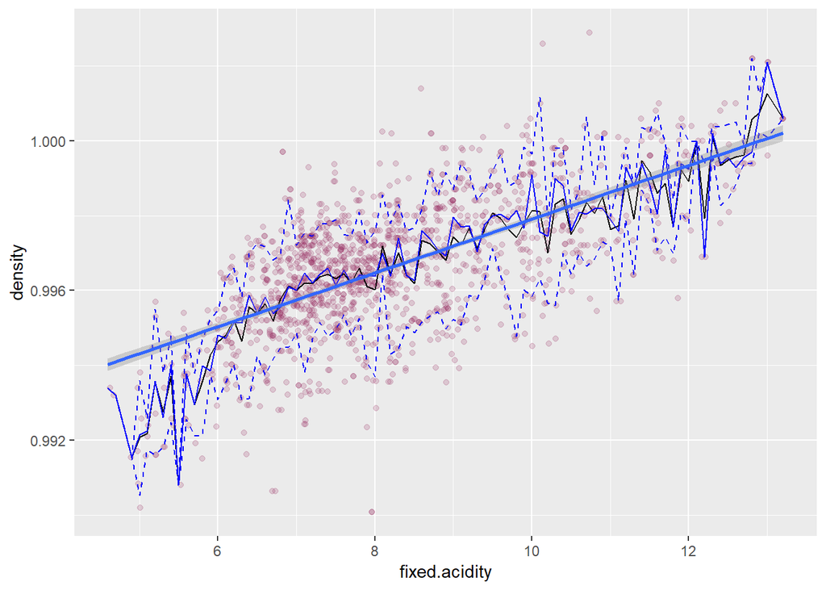

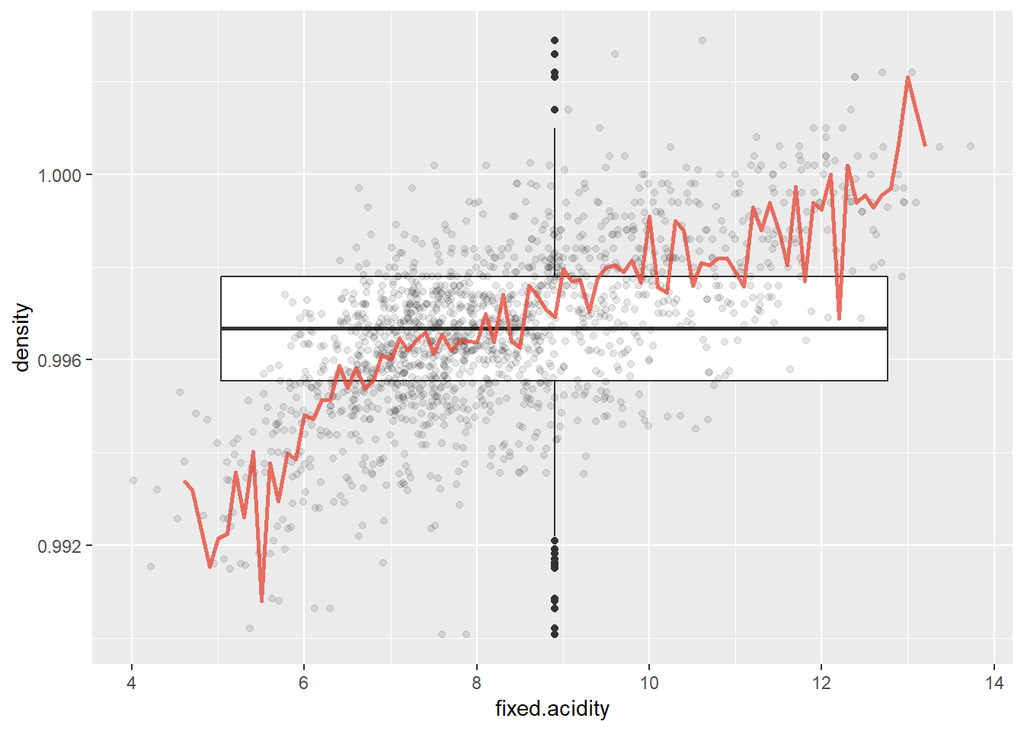

There is a strong Positive linear relationship between fixed acidity and density.

As fixed acidity increases so does wine density. Therefore, the denser the wine, the less likely it is to evaporate quickly.

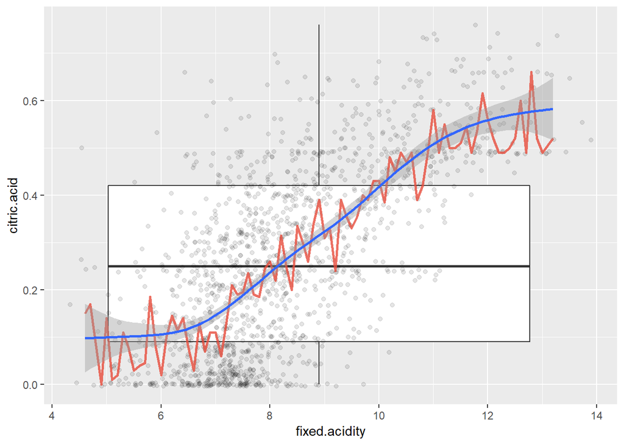

We have a strong positive relationship between fixed acidity and citric acid, r = 0.69.

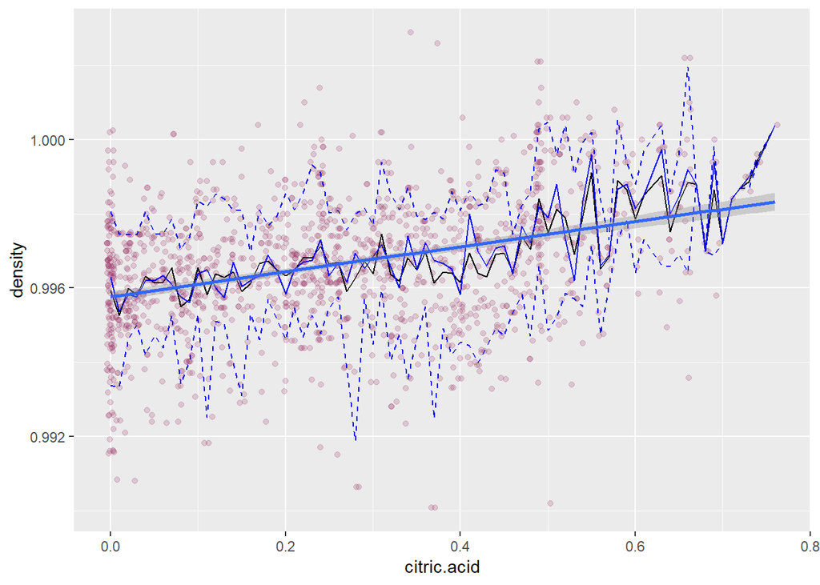

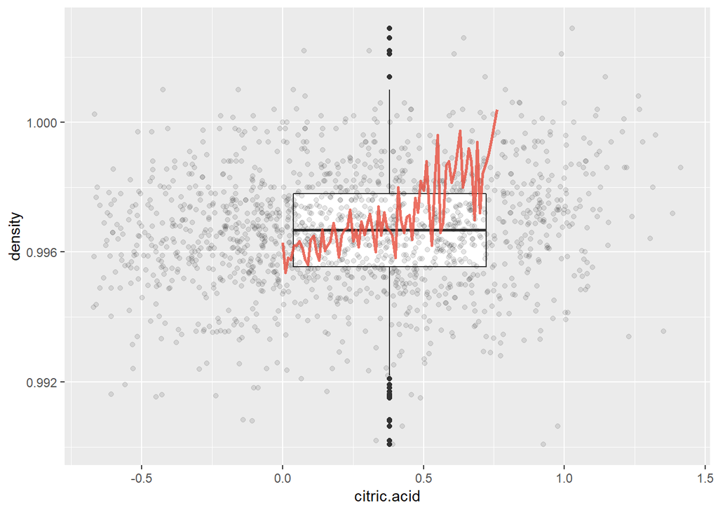

Citric acid and density have a moderate uphill linear relationship (0.36) As one variable increases so does the other.

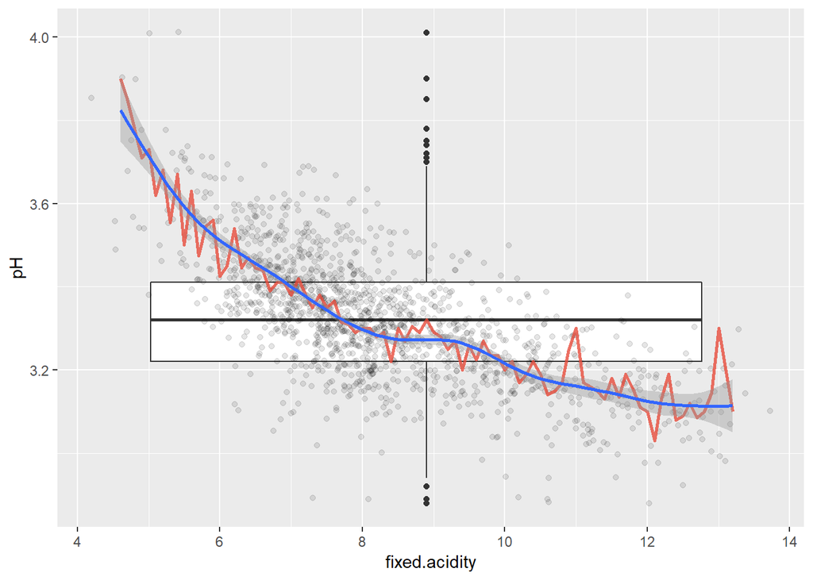

Fixed acidity and pH has a negative linear relationship.

This is a downhill relationship with a correlation coefficient at -0.70.

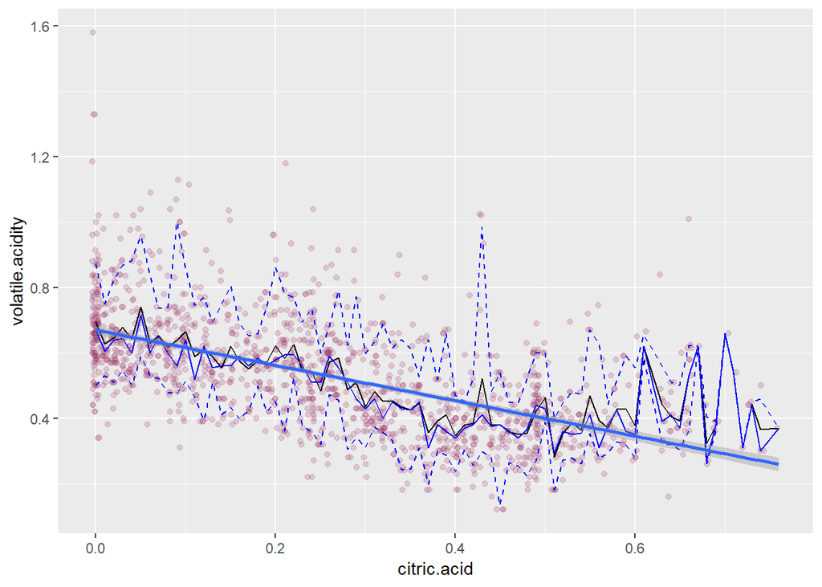

Citric acid and volatile acidity has a moderate negative correlation at -0.57.

This indicates that larger amounts of citric acid means smaller amounts of volatile acidity. Fresher wines do not appear to have large amounts of acetic acid.

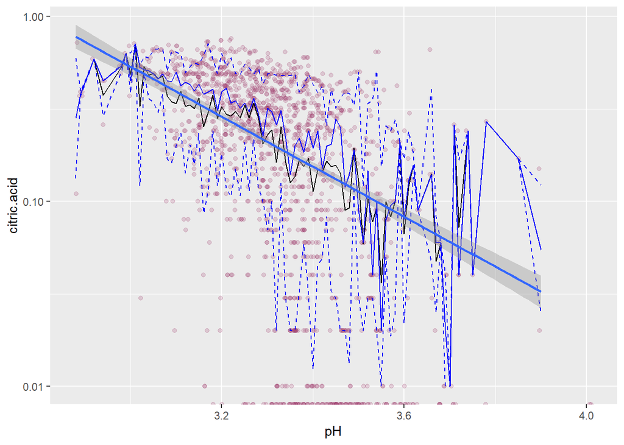

Ph increases with the lower amounts of citric acid. The relationship is not a strong one, it is a moderate negative relationship at a correlation coefficient of -0.517

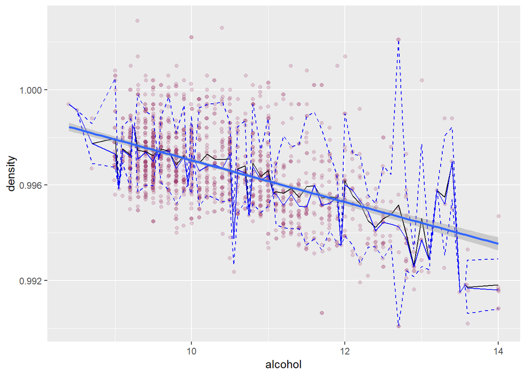

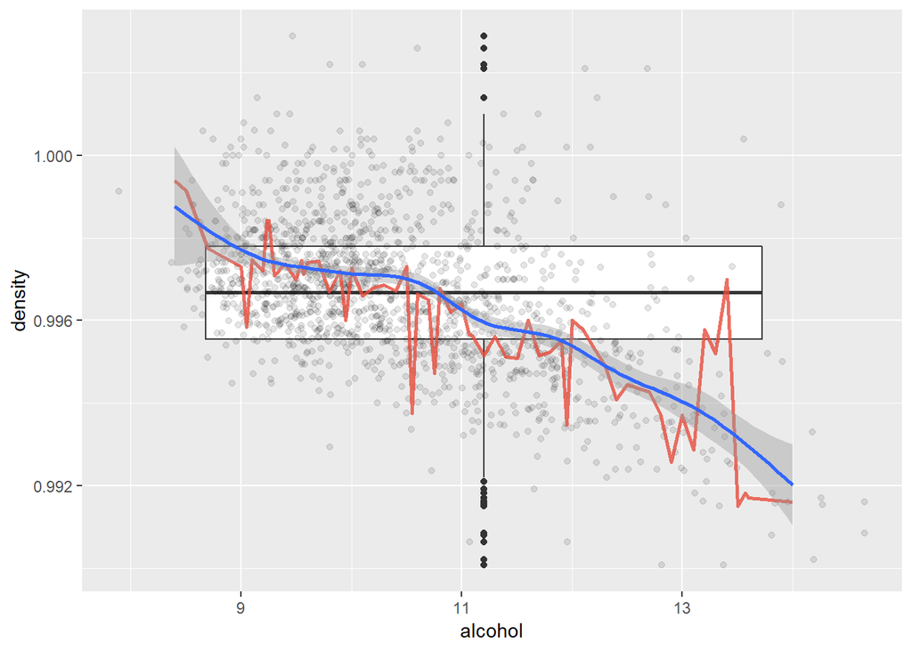

The higher the alcohol content, the less dense the wines appear to be.

# Bivariate Analysis

### Talk about some of the relationships you observed in this part of the investigation. How did the feature(s) of interest vary with other features in the dataset?

It appears that (other than alcohol content) sulphates, citric acid and fixed acidity levels determine which red wines have a decent quality rating, since these variables have a positive linear relationship with quality.

Fixed acidity and density have a strong Positive linear relationship (0.65). Since fixed acidity and quality has a positive linear relationship and fixed acidity and density have a positive linear relationship, you would think that quality and density also might have a positive linear relationship. However, quality and density have a weak negative relationship with a correlation coefficient of -0.18. But This actually makes sence since fixed acidity has a very weak relationship with a correlation coefficeint of 0.12, Which is not really significant.

### Did you observe any interesting relationships between the other features (not the main feature(s) of interest)?

# What was the strongest relationship you found?

I have found that alcohol has the most positive linear relationship with quality.

Another interesting strong relationship was between fixed acidity and pH with a correlation coefficient at -0.70.

# Multivariate Plots Section

Since alcohol, sulphates, and citric acid levels have the most positive linear relationship with quality, we will look at these variables more closely. We will also look closer and quality and volatile acidity, since volatile acidity has the strongest negative linear relationship with quality

Alcohol has the strongest positive relationship with quality, therefore, I will explore the relationship between these two variables against a third variable.

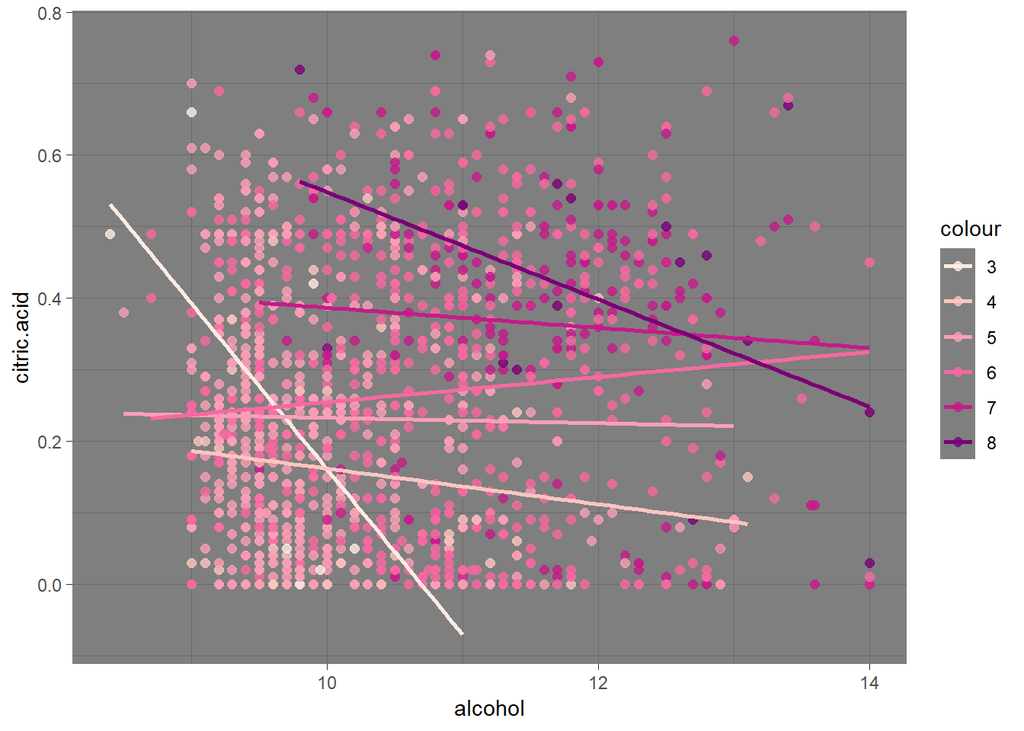

This plot seems to indicate that higher quality wines have a higher level of citric acid, as well as, alcohol content. However, there there are a number of good quality wines (rating 6) that do have a low level of citric acid present. This seems to be consistent with our correlation coefficient of 0.24 for quality and citric acid.

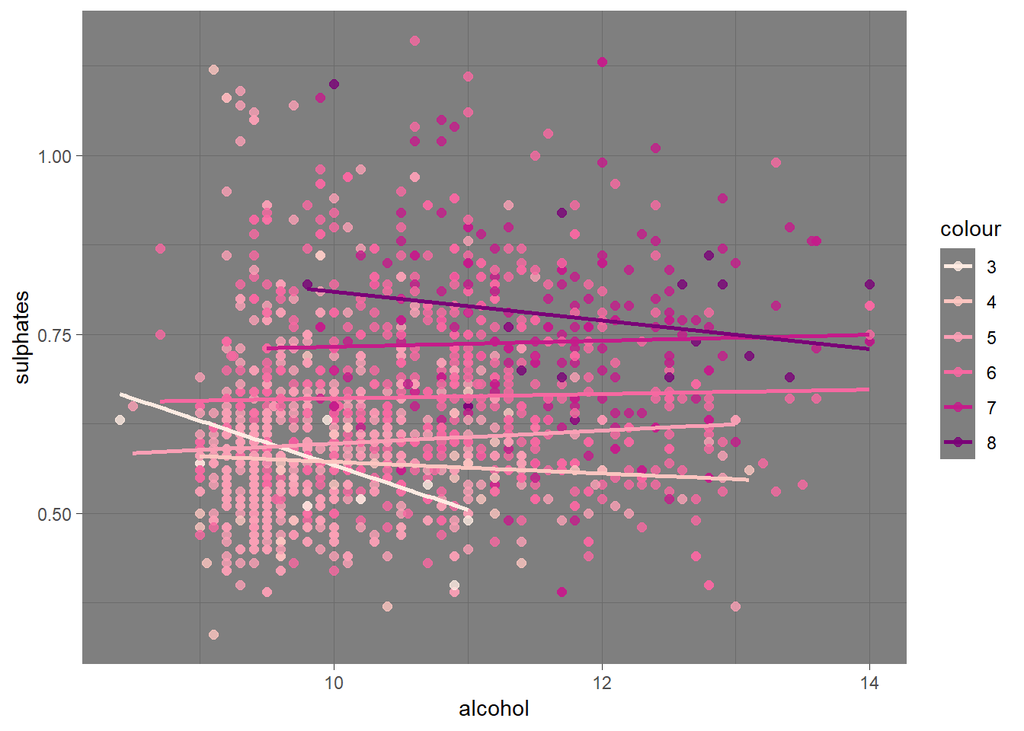

This plot results are consistent with our earlier analysis that sulphates and quality is moderately positively correlated. Most wines with a high quality rating seem to be clustering more to th eto right side of the plot Quality typically increases as both alcohol and sulphates increase

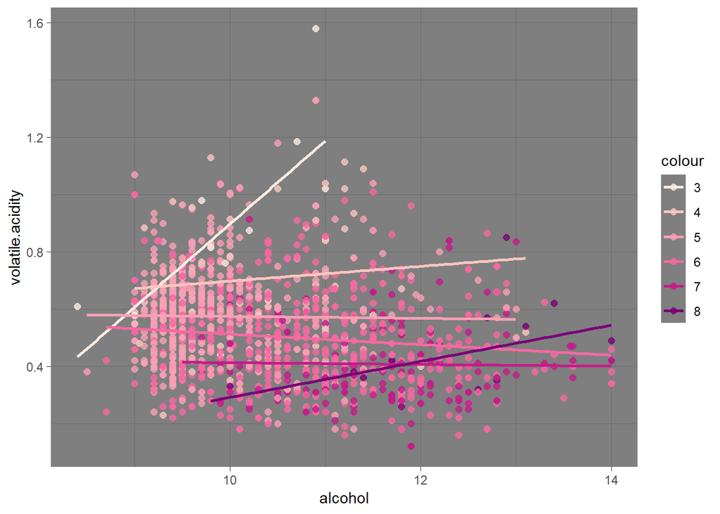

Volatile acidity negatively correlates with both quality and alcohol, with both variables having a weak relationship with volatile acidity.

We can see in the plot that lower quality wine, those with a rating between 3 and 4, have noticably higher level of volatile acidity. Where as, high quality wines, ratings of 7 and 8, have a much lower presence of volatile acidity. Wines with quality ratings of 5 and 6 can be seen spread about the graph but still with a reasonably low level of volatile acidity.

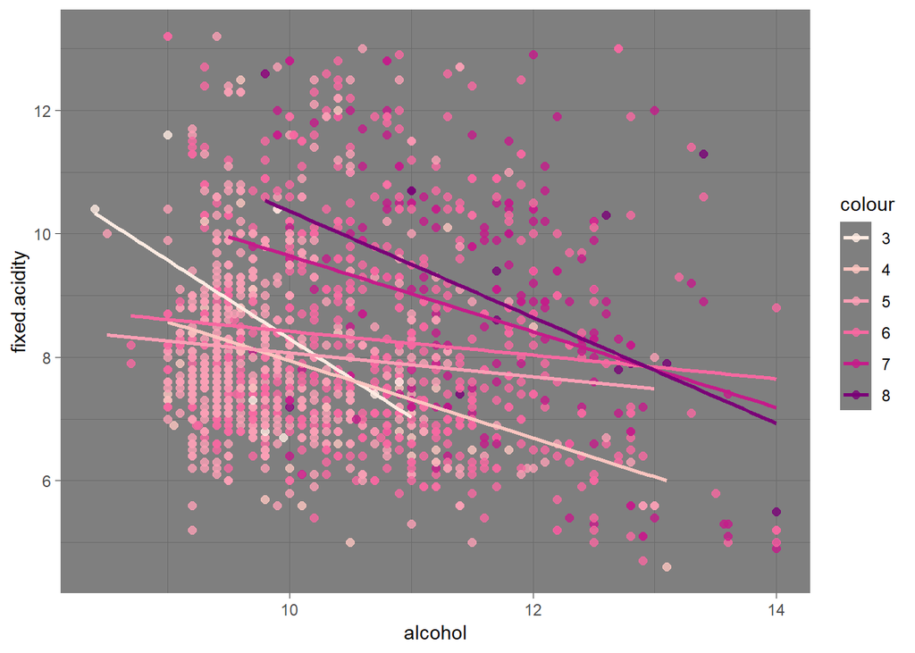

Alcohol and fixed acidity do not seem to have any relationship at all, if any relationship is present it is a very weak negative relationship.

Fixed acidity and quality have positive linear relationship, but a very weak one. There does not seem to be any definite indication on the graph that higher quality wines have a higher presence of fixed acidity

# Multivariate Analysis

The main relationships that were explored were those that correlated higher with quality than other variables.

Out of all of our observations, alcohol seems to be a big determining factor for decent quality wines. However, higher amounts of alcohol content together with higher levels of citric acid seem to produce the best quality wines. Also, Wines with a higher presence of sulphates along with alcohol rate much better than those wines who have lower levels of sulphates.

As mentioned above, fixed acidity does not seem determine weather a wine is of good quality or not.

We have evidence to suggest that volatile acidity does correlate negatively with quality. A higher concentration of volatile acidity, along with lower levels of alcohol contributes to lower quality wines.

# Final Plots and Summary

### Plot One

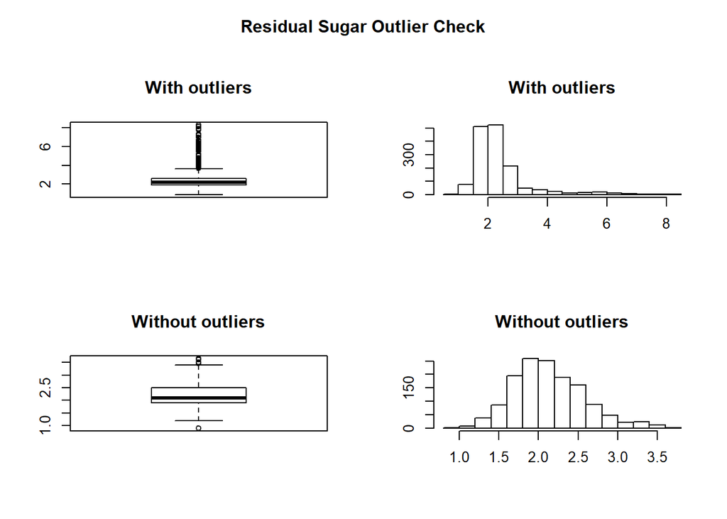

```
## Outliers identified: 118
## Propotion (%) of outliers: 8.5
## Mean of the outliers: 5.15
##  Mean without removing outliers: 2.42
##  Mean if we remove outliers: 2.18
```

### Description One

I chose this plot because it shows us the variable with the most extreme outliers, it gives us a visualization, through a histogram, and it gives us a sense of the distribution with outliers and then without, if they were to be removed.

### Plot Two

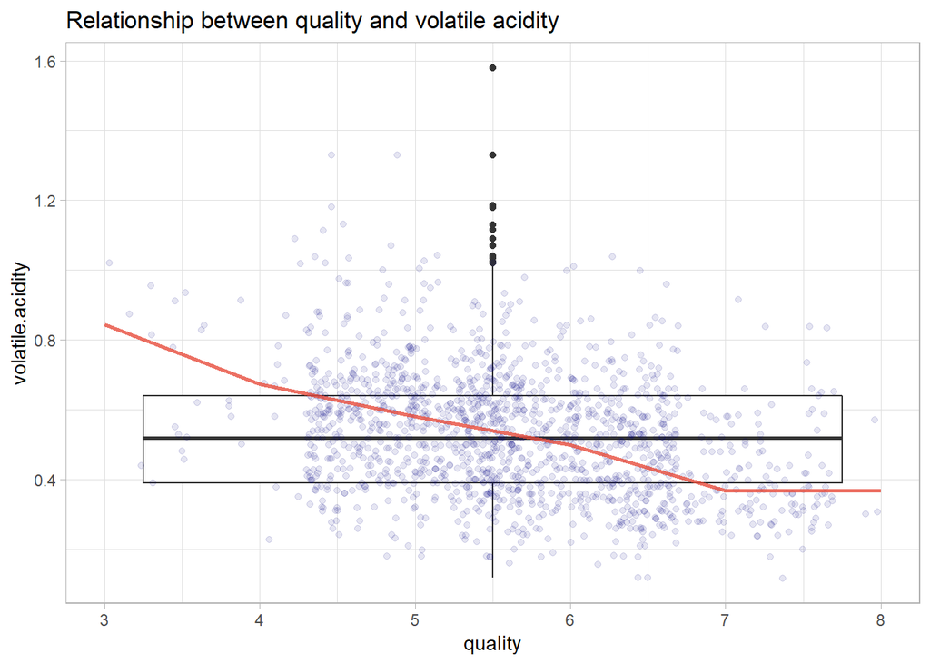

### Description Two

I chose this plot because it shows the variable with the strongest negative linear relationship with quality. We have focused mainly of which variables contribute to a good quality wine, during our analysis, we found evidence to suggest that higher levels of volatile acidity are present in wines with poorer quality ratings, as high levels can lead to an unpleasant, vinegar taste.

### Plot Three

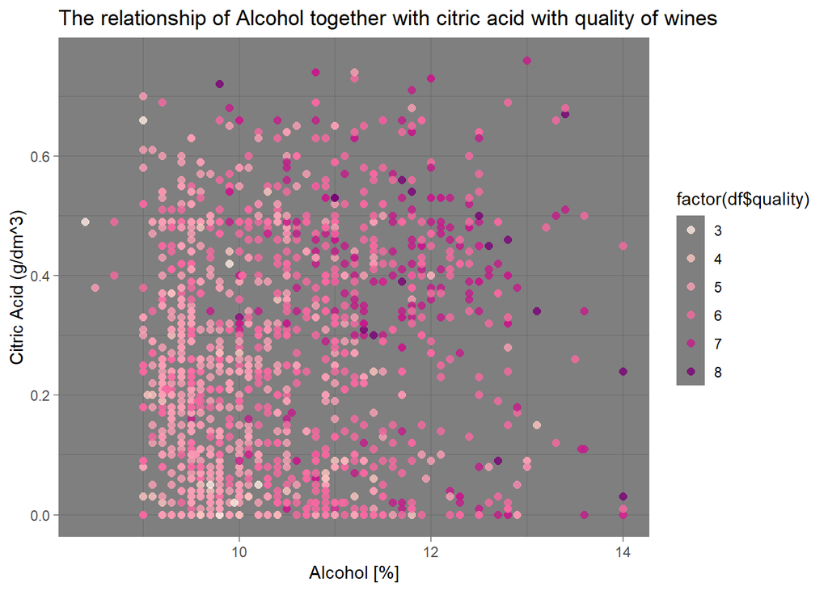

### Description Three

This scatter plot shows the two variables with the strongest positive correlation with quality. Our analysis suggests that alcohol is a big detrermining factor for good quality wines. Also, higher levels of citric acid, along with, higher alcohol content produce higher quality wines. Its important to note that the plot does show that some high quality wines (7 and 8) do have lower levels of citric acid and alcohol content and still maintains a high rating.

# Reflection

Initially we started off with a dataset that had 1599 0bservations and had 13 variables. It was decided that the column ‘x’ was not needed as it represented as an index. This column was removed and we were left with 12 variables. Through our analysis we found that some variables had extreme outliers that were skewing the data and distribution. These outliers were removed and left us with a total of 1501 observations.

Our analysis provided evidence that the most influencial variabes on wine quality were citric acid, sulphates, alcohol and volotile acidity.

Wines with a higher alcohol content had a higher quality rating. This was true for citric acid too.

It was a suprising to discover that rididual sugar had little impact on the quality of wine. The relationship was very weak and i had initially assumed that the sweetness of wine would determine the quality.

Some limitations of the dataset are that it was not clear as to what was causing the outliers, whether they were due to misprint or if its a true representation of the actual findings. This information would of been useful to determine whether or not to remove outliers and the implications on the data.

furthermore, having identified the main trends in the data, prediction models could be introduced as they would be helpful to determine whether these trends could be used to predict the wine quality based on the physicochemical attributes.

# References:

-https://www.r-bloggers.com/identify-describe-plot-and-remove-the-outliers-from-the-dataset/

-Programming with R. Creating Functions. https://swcarpentry.github.io/r-novice-inflammation/02-func-R/

-Acids in wine. https://en.wikipedia.org/wiki/Acids_in_wine